# MATH 253 Introduction Exercises

Danny Kaplan

Statistical Computing and Machine Learning

## ISL 2.4.2

Is it a classification or regression problem?

1. The response variable, CEO salary, is a quantitative variable, so this is a regression problem.
2. The response variable has levels *success* or *failure*, so this is a classification problem.
3. The response variable, percent change in the US dollar, is quantitative, so this is a regression problem.

## ISL 2.4.7

1. Compute the Euclidean distance between each observation and the test point, $X_1 = X_2 = X_3 = 0$.
   - Obs. 1: $\sqrt{(0-0)^2 + (3-0)^2 + (0-0)^2} = 3$
   - Obs. 2: $\sqrt{(2-0)^2 + (0-0)^2 + (0-0)^2} = 2$
   - Obs. 3: $\sqrt{(0-0)^2 + (1-0)^2 + (3-0)^2} = \sqrt{10}$
   - Obs. 4: $\sqrt{(0-0)^2 + (1-0)^2 + (2-0)^2} = \sqrt{5}$
   - Obs. 5: $\sqrt{(-1-0)^2 + (0-0)^2 + (1-0)^2} = \sqrt{2}$
   - Obs. 6: $\sqrt{(1-0)^2 + (1-0)^2 + (1-0)^2} = \sqrt{3}$
2. What is our prediction with $K = 1$? Observation 5 is closest to the test point, so the output will be the value associated with observation 5: Green
3. What is our prediction with $K = 3$? Observations 5, 6, and 2 are the closest. Observation 5 votes “Green,” observations 2 and 6 both vote “Red.” Red is the winner!
4. If the Bayes decision boundary in this problem is highly nonlinear, then would we expect the best value for $K$ to be large or small? Models with large $K$ tend to change value slowly. Boundaries that are highly nonlinear require model values that can change rapidly. This argues for small $K$.

## ISL 2.4.8

Using the `College` data set from the `ISLR` package … rather than reading it in with `read.csv()`.

```r
library(ISLR)
data(College)
```

Not so much point in giving a solution here. In the problem they walk through the commands needed.

## ISL 2.4.9

```r
library(ISLR)
data(Auto)
```

Making sure the NAs are removed:

```r
Auto <- Auto[ - complete.cases(Auto), ]
```

1. Which predictors are quantitative and which are qualitative? You could use `summary(Auto)` to look at each variable, or use the `class()` function to calculate the answer. `lapply()` applies the function specified by `FUN` to each variable in a data frame.

   ```r
   lapply(Auto, FUN = class)
   ```

   ```
   ## $mpg
   ## [1] "numeric"
   ##
   ## $cylinders
   ## [1] "numeric"
   ##
   ## $displacement
   ## [1] "numeric"
   ##
   ## $horsepower
   ## [1] "numeric"
   ##
   ## $weight
   ## [1] "numeric"
   ##
   ## $acceleration
   ## [1] "numeric"
   ##
   ## $year
   ## [1] "numeric"
   ##
   ## $origin
   ## [1] "numeric"
   ##
   ## $name
   ## [1] "factor"
   ```

2. What is the range of each quantitative predictor?

   ```r
   with(Auto, range(mpg))
   ```

   ```
   ## [1]  9.0 46.6
   ```

   ```r
   with(Auto, range(cylinders))
   ```

   ```
   ## [1] 3 8
   ```

   ```r
   with(Auto, range(acceleration))
   ```

   ```
   ## [1]  8.0 24.8
   ```

   ```r
    # and so on.
   ```

3. What is the mean and standard deviation of each quantitative predictor?

   ```r
   with(Auto, c(mean(mpg), sd(mpg)))
   ```

   ```
   ## [1] 23.459847  7.810128
   ```

   ```r
   with(Auto, c(mean(cylinders), sd(cylinders)))
   ```

   ```
   ## [1] 5.465473 1.703152
   ```

   ```r
   with(Auto, c(mean(acceleration), sd(acceleration)))
   ```

   ```
   ## [1] 15.550384  2.756557
   ```

   ```r
    # and so on.
   ```

4. Remove the 10th through 85th observations

```r
For_part_d <- Auto[ - (10:85), ]
# then statements as in c.
```

5. Investigate the predictors graphically

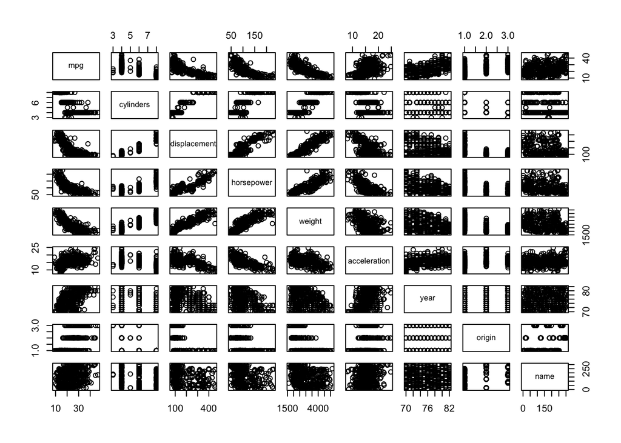

```r
pairs(Auto)
```

f. Might any of the other predictors be useful to predict `mpg`? The first row (or column, if you like) shows the correlations with `mpg`. Most of the variables show a correlation with `mpg`, e.g. cylinders, displacement, horsepower, wieght, acceleration, and year.